# R Notebook

Trying to be more systematic about constrained CCA.

Doing RDA instead of CCA to see what happens

I think I just need one RDA?

## Steps from before

Step 1 – CCA with Station and Depth and Size

Step 2 – CCA with Size, factoring out Station and Depth

Step 3 – CCA with Size, factoring out Station and Depth, removing Free-living microbes

Step 4 - CCA with Size, factoring out Station and Depth, > 5 micron only

Try to get nice looking CCA plots with symbols on each

# To do – I wonder what happens if I log transform the size class instead of sqrt transforming

```r
library(ggvegan)
library(vegan)
library(tidyverse)
library(cowplot)
library(here)
library(flextable)
library(ftExtra)
#source(here("RScripts", "InitialProcessing_3.R"))
source(here("RLibraries", "ChesapeakePersonalLibrary.R"))
env1 <- attach(here("RDataFiles", "InitialProcessing_3_minimal.RData"))
set.seed(10033)
```

```r
nonSpikes20 <- env1$nonSpikes20
sampleData <- env1$sampleData
```

# Setup

```r
wideASVs <- nonSpikes20 %>%
  mutate(copiesPerLPermm = copiesPerL/Bin_Size) %>%
  #filter(Depth != "Oxy") %>%
  #mutate(copiesPerLPermm = copiesPerL/MassperLiter) %>% # temporary swap out just to see
  select(ID, ASV, copiesPerLPermm) %>%
  pivot_wider(id_cols = ID, names_from = ASV, values_from = copiesPerLPermm) %>%
  column_to_rownames("ID") %>% na.omit()
```

```r
sampleData01 <- sampleData[match(rownames(wideASVs), sampleData$ID),]
```

```r
wideASVs_log <- log(wideASVs + 1)
wideASVs_scaled <- scale(wideASVs_log)
```

## Plot settings

```r
filterSizes <- c(0.2, 1.2, 5, 20, 53, 180, 500)
myGuides <-   guides(shape = guide_legend(ncol = 2), fill = guide_legend(ncol = 2),
         size = guide_legend(ncol = 2),
         color = guide_legend(ncol = 2))

myPlotDetails <- list(
  scale_fill_viridis_d(option = "plasma") ,
  scale_shape_manual(values = rep(21:25, 2)),
  scale_color_manual(values = c("green2", "blue", "black")) ,
  scale_size(breaks = sqrt(filterSizes),
             labels = filterSizes) ,
  theme_bw(),
  myGuides
)
```

# RDA with everything

but pretty this time

```r
rdaConstrained <- rda(wideASVs_log ~ lat + Depth2 + log10(Size_Class), data = sampleData01)
```

```r
rdaConstrained
```

```
Call: rda(formula = wideASVs_log ~ lat + Depth2 + log10(Size_Class), data = sampleData01)

                Inertia Proportion Rank
Total         1.090e+04  1.000e+00
Constrained   3.183e+03  2.921e-01    3
Unconstrained 7.714e+03  7.079e-01   71
Inertia is variance

Eigenvalues for constrained axes:
  RDA1   RDA2   RDA3
2030.6  856.5  296.0

Eigenvalues for unconstrained axes:
   PC1    PC2    PC3    PC4    PC5    PC6    PC7    PC8
1814.8  919.0  643.6  553.3  288.0  251.2  215.2  212.9
(Showing 8 of 71 unconstrained eigenvalues)
```

```r
anova(rdaConstrained)
```

```
Permutation test for rda under reduced model
Permutation: free
Number of permutations: 999

Model: rda(formula = wideASVs_log ~ lat + Depth2 + log10(Size_Class), data = sampleData01)
         Df Variance      F Pr(>F)
Model     3   3183.1 9.7662  0.001 ***
Residual 71   7713.6
---
Signif. codes:  0 ‘***’ 0.001 ‘**’ 0.01 ‘*’ 0.05 ‘.’ 0.1 ‘ ’ 1
```

```r
mooAnova <- anova(rdaConstrained, by = "margin", permutations = 9999)
mooAnova
```

```
Permutation test for rda under reduced model
Marginal effects of terms
Permutation: free
Number of permutations: 9999

Model: rda(formula = wideASVs_log ~ lat + Depth2 + log10(Size_Class), data = sampleData01)
                  Df Variance       F Pr(>F)
lat                1    834.4  7.6799 0.0001 ***
Depth2             1    355.6  3.2736 0.0015 **
log10(Size_Class)  1   1952.8 17.9750 0.0001 ***
Residual          71   7713.6
---
Signif. codes:  0 ‘***’ 0.001 ‘**’ 0.01 ‘*’ 0.05 ‘.’ 0.1 ‘ ’ 1
```

```r
mooAnova$Variance/sum(mooAnova$Variance) # proportions explained
```

```
[1] 0.07685399 0.03275936 0.17987855 0.71050811
```

```r
sum(mooAnova$Variance[1:3])/sum(mooAnova$Variance) # same as total variance explained? Very similar
```

```
[1] 0.2894919
```

Lets make this into a nice table Columns are variance?, percent variance explained, F, P And a row added for residual and for total

```r
# note that I'm using a non breaking space in the percent variance variable name
# unicode: 00a0
betaTable <- mooAnova %>% broom::tidy() %>%
  mutate(`% Variance` = Variance/sum(Variance)) %>%
  mutate(term = recode(term, lat = "Latitude", Depth2 = "Depth", `log10(Size_Class)` = "√Size Class")) %>%
  select(Term = term, DF = df, Variance, `% Variance`, T = statistic, p = p.value) %>%
    mutate(Variance = format(Variance, digits = 3),
         `% Variance` = format(`% Variance`, digits = 2),
         `T` = if_else(is.na(`T`), "", format(`T`, digits = 2)),
         p = if_else(p < 0.001, "< 0.001", paste0(" ", format(round(p, 3), digits = 1, scientific = FALSE)))
         ) %>%
  flextable() %>%
  align(j = -c(1), align = "right", part = "all") %>%
  bold(i = ~ p < 0.05, j = "p") %>%
  italic(j = "p", part = "header") %>%
  identity()
betaTable
```

| Term | DF | Variance | % Variance | T | p |
| --- | --- | --- | --- | --- | --- |
| Latitude | 1 | 834 | 0.077 | 7.7 | < 0.001 |
| Depth | 1 | 356 | 0.033 | 3.3 | 0.002 |
| √Size Class | 1 | 1953 | 0.180 | 18.0 | < 0.001 |
| Residual | 71 | 7714 | 0.711 |  |  |

```r
betaTable %>% save_as_docx(path = here::here("Tables", "betaTable.docx"))
```

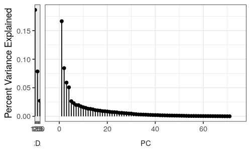

```r
CCA_Eigen_Plot <- function(CCA){
  CCAPctVarPlot <- enframe(c(CCA$CCA$eig/CCA$tot.chi,CCA$CA$eig/CCA$tot.chi), name = "CA", value = "PctVarExplained") %>%
  mutate(CAN = parse_number(CA)) %>%
    mutate(Type = str_remove(CA, "[:digit:].*")) %>%
    mutate(Type = factor(Type, levels = c("RDA", "PC"))) %>%
  ggplot(aes(x = CAN, y = PctVarExplained)) +
  geom_point() +
  geom_segment(aes(x = CAN, xend = CAN, y = 0, yend = PctVarExplained)) +
  labs(y = "Percent Variance Explained", x = NULL) +
   #geom_vline(xintercept = 7.5, color = "grey") +
    facet_grid(~Type, scales = "free_x", space = "free_x", switch = "both") +
  scale_x_continuous(expand = c(0.1,0)) +
  theme_bw() +
  theme(strip.background = element_blank(),
           strip.placement = "outside", legend.position = "none")
CCAPctVarPlot
}

CCA_Eigen_Plot(rdaConstrained)
```

This looks pretty awful, but Its not going in the paper I don’t think so I’ll leave it for now.

## Main CCA Doing and Plotting Functions

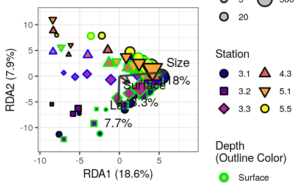

```r
my_fortify_function <- function(ccaConstrained){
  fortify(ccaConstrained) %>% filter(Score %in% c("sites", "biplot")) %>% # not sure what constraints are
    left_join(microbialAbundance, by = c("Label" = "ID"))
}

my_percent_explained <- function(ccaConstrained){
  loc_anova <- anova(ccaConstrained, by = "margin")
  loc_props <- loc_anova$Variance/sum(loc_anova$Variance)
  loc_props_nr <- loc_props[1:(length(loc_props)-1)]
  loc_props_nr
}

My_Constrained_RDA_Plot_Type1 <- function(ccaConstrainedFort, ccaConstrained){
  ccaConstrainedPlot <- ccaConstrainedFort %>%
    filter(Score == "sites") %>%
    mutate(Depth = recode(Depth, `Oxy` = "Oxycline")) %>%
    select(Station, Depth, Size_Class, everything()) %>%
    ggplot(aes(x = RDA1, y = RDA2,
               fill = as.factor(Station),
               shape = as.factor(Station),
               size = sqrt(Size_Class),
               color = as.factor(Depth)
    )) +
    geom_point(stroke = 1) +
    coord_fixed(sqrt(ccaConstrained$CCA$eig[2]/ccaConstrained$CCA$eig[1])) +


    #geom_point(aes(x  = CCA1, y = CCA2), data = ccaConstrainedFort %>% filter(Score == "biplot"), inherit.aes = FALSE) +
    labs(x = paste0("RDA1 (", round(ccaConstrained$CCA$eig[1]/ccaConstrained$tot.chi, 3) * 100, "%)"),
         y = paste0("RDA2 (", round(ccaConstrained$CCA$eig[2]/ccaConstrained$tot.chi, 3) * 100, "%)"),
         col = "Depth\n(Outline Color)",
         fill = "Station",
         shape = "Station",
         size = "Size Class") +
        geom_segment(aes(x = 0, y = 0, xend  = RDA1 * 6, yend = RDA2 * 6), data = ccaConstrainedFort %>% filter(Score == "biplot"), inherit.aes = FALSE, size = 1, alpha = 0.9, arrow = arrow(length = unit(0.1, "in")), color = "gray20") +
    geom_text(aes(label = Label2, x = RDA1 * 7.5, y = RDA2 * 7.5),
               color = "black", alpha = 1,
               show.legend = FALSE,
               data = ccaConstrainedFort %>%
                 filter(Score == "biplot") %>%
                 mutate(Label = recode(Label, lat = "Lat",
                                       `log10(Size_Class)` = "Size",
                                       `Depth2Surface` = "Surface",
                                       `log10(Oxygen + 0.03)` = "Oxygen"
                 )) %>%
                 mutate(PctExplained = my_percent_explained(ccaConstrained)) %>%
                 mutate(Label2 = paste0(Label, "\n", round(PctExplained, 3) * 100, "%")) %>%
                 # Fates, please forgive me my hard-coding.
                 # I just need the biplot segment labels away from the origin.
                 mutate(RDA1 = if_else(sqrt(RDA1^2 + RDA2^2) < 0.5, RDA1 * 2, RDA1)) %>% # was 1.5
                 mutate(RDA2 = if_else(sqrt(RDA1^2 + RDA2^2) < 0.5, RDA2 * 2, RDA2)) %>%
                 identity()
    ) +

    lims(x = c(range(ccaConstrainedFort$RDA1)[1] * 1.1, range(ccaConstrainedFort$RDA1)[2] * 1.7), y = range(ccaConstrainedFort$RDA2 * 1.1)) + # BOOKMARK
    myPlotDetails +
    guides(color = guide_legend(override.aes = list(shape = 21, size = 2, stroke = 2, fill = "gray")),
           shape = guide_legend(override.aes = list(size = 3)),
           size = guide_legend(override.aes = list(shape = 21, color = "black", fill = "gray"), ncol = 2)
    )
  ccaConstrainedPlot
}

My_Constrained_RDA_Plot_Type1_wFort <- function(ccaConstrained){
  ccaConstrainedFort <- my_fortify_function(ccaConstrained)
  My_Constrained_RDA_Plot_Type1(ccaConstrainedFort, ccaConstrained)
}


mainRDA <- My_Constrained_RDA_Plot_Type1_wFort(rdaConstrained)
mainRDA
```

```r
ggsave(here::here("Figures", "mainRDA.png"),mainRDA, height = 4.4, width = 6)
ggsave(here::here("Figures", "mainRDA.svg"),mainRDA, height = 4.4, width = 6)
```

Axis 1 vs 3 Not the most dry code I’ve ever done, but I’m not sure how to actually do this, so I’m manually changing the axes

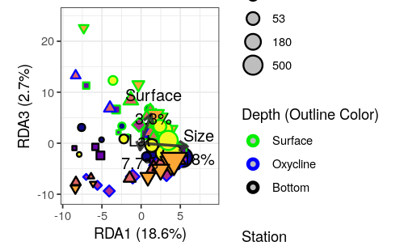

```r
My_Constrained_RDA_Plot_Type1_13 <- function(ccaConstrainedFort, ccaConstrained){
  ccaConstrainedPlot <- ccaConstrainedFort %>%
  filter(Score == "sites") %>%
  mutate(Depth = recode(Depth, `Oxy` = "Oxycline")) %>%
  select(Station, Depth, Size_Class, everything()) %>%
  ggplot(aes(x = RDA1, y = RDA3,
             fill = as.factor(Station),
             shape = as.factor(Station),
             size = sqrt(Size_Class),
             color = as.factor(Depth)
             )) +
 geom_point(stroke = 1) +
 coord_fixed(sqrt(ccaConstrained$CCA$eig[2]/ccaConstrained$CCA$eig[1])) +

  geom_segment(aes(x = 0, y = 0, xend  = RDA1 * 6, yend = RDA3 * 6), data = ccaConstrainedFort %>% filter(Score == "biplot"), inherit.aes = FALSE, size = 1, alpha = 0.9, arrow = arrow(length = unit(0.1, "in")), color = "gray20") +
  #geom_point(aes(x  = CCA1, y = CCA2), data = ccaConstrainedFort %>% filter(Score == "biplot"), inherit.aes = FALSE) +
    labs(x = paste0("RDA1 (", round(ccaConstrained$CCA$eig[1]/ccaConstrained$tot.chi, 3) * 100, "%)"),
       y = paste0("RDA3 (", round(ccaConstrained$CCA$eig[3]/ccaConstrained$tot.chi, 3) * 100, "%)"),
       col = "Depth (Outline Color)",
       fill = "Station",
       shape = "Station",
       size = "Size Class") +
     geom_text(aes(label = Label2, x = RDA1 * 7.5, y = RDA3 * 7.5),
            color = "black", alpha = 1,
            show.legend = FALSE,
           data = ccaConstrainedFort %>%
             filter(Score == "biplot") %>%
             mutate(Label = recode(Label, lat = "Lat",
                                   `log10(Size_Class)` = "Size",
                                   `Depth2Surface` = "Surface"
                                   )) %>%
             mutate(PctExplained = my_percent_explained(ccaConstrained)) %>%
             mutate(Label2 = paste0(Label, "\n", round(PctExplained, 3) * 100, "%"))
             ) +
    lims(x = c(range(ccaConstrainedFort$RDA1)[1] * 1.1, range(ccaConstrainedFort$RDA1)[2] * 1.7), y = range(ccaConstrainedFort$RDA3 * 1.1)) +
  myPlotDetails +
  guides(color = guide_legend(override.aes = list(shape = 21, size = 2, stroke = 2, fill = "gray")),
         shape = guide_legend(override.aes = list(size = 3)),
         size = guide_legend(override.aes = list(shape = 21, color = "black", fill = "gray"))
         )
ccaConstrainedPlot
}

My_Constrained_RDA_Plot_Type1_wFort_13 <- function(ccaConstrained){
  ccaConstrainedFort <- my_fortify_function(ccaConstrained)
  My_Constrained_RDA_Plot_Type1_13(ccaConstrainedFort, ccaConstrained)
}


mainRDA13 <- My_Constrained_RDA_Plot_Type1_wFort_13(rdaConstrained)
mainRDA13
```

```r
ggsave(here::here("Figures", "mainRDA_axis1and3.png"),mainRDA13, height = 4, width = 6)
ggsave(here::here("Figures", "mainRDA_axis1and3.svg"),mainRDA13, height = 4, width = 6)
```

EnvRDA123 <- plot_grid( plot_grid( EnvRDA + theme(legend.position = “none”), EnvRDA13 + theme(legend.position = “none”), ncol = 1, labels = c(“A”, “B”), label_y = 0.9 ), legend_rda, rel_widths = c(10, 2) ) EnvRDA123

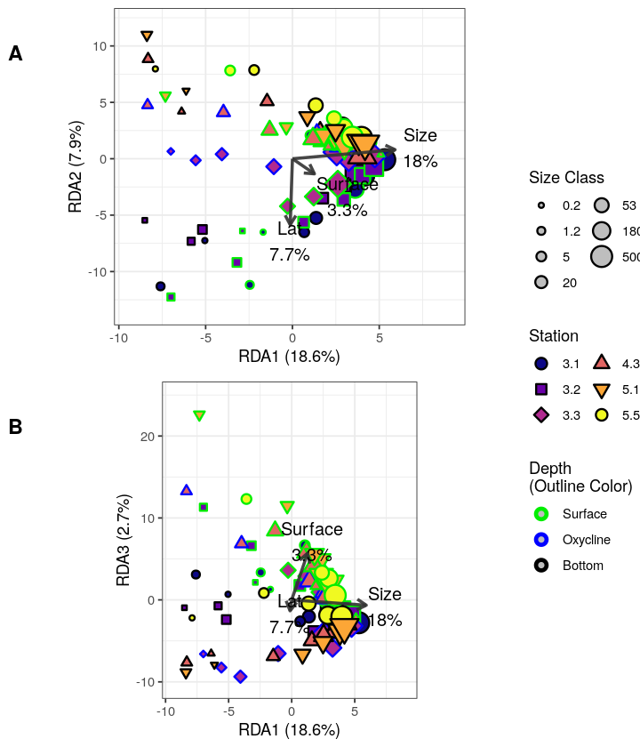

```r
legend_rda <- get_legend(
  mainRDA + theme(legend.box.margin = margin(0, 0, 0, 0))
                         )

PosRDA123 <- plot_grid(
  plot_grid(
    mainRDA + theme(legend.position = "none"),
    mainRDA13 + theme(legend.position = "none"),
    ncol = 1, labels = c("A", "B"), label_y = 0.9
  ),
  legend_rda, rel_widths = c(10, 2)
)
PosRDA123
```

```r
ggsave(here("Figures", "PosRDA_123.png"), plot = PosRDA123, height = 7, width = 6)
ggsave(here("Figures", "PosRDA_123.svg"), plot = PosRDA123, height = 7, width = 6)
```

```r
rdaConstrainedFort <- fortify(rdaConstrained) %>% filter(Score %in% c("sites", "biplot")) %>% # not sure what constraints are
 left_join(microbialAbundance, by = c("Label" = "ID"))
```

# As above, but this time without the 0.2 micron data

```r
sampleData_NoFree <- sampleData01 %>% filter(Size_Class > 1)
wideASVs_log_NoFree <- wideASVs_log[rownames(wideASVs_log) %in% sampleData_NoFree$ID,]
wideASVs_log_NoFree <- wideASVs_log_NoFree[match(sampleData_NoFree$ID, rownames(wideASVs_log_NoFree)),]
```

```r
rdaConstrained_NoFree <- rda(wideASVs_log_NoFree ~ lat + Depth2 + log10(Size_Class), data = sampleData_NoFree)
```

```r
rdaConstrained_NoFree
```

```
Call: rda(formula = wideASVs_log_NoFree ~ lat + Depth2 + log10(Size_Class), data = sampleData_NoFree)

                Inertia Proportion Rank
Total         9330.6524     1.0000
Constrained   3636.1895     0.3897    3
Unconstrained 5694.4629     0.6103   62
Inertia is variance

Eigenvalues for constrained axes:
  RDA1   RDA2   RDA3
2535.1  764.4  336.7

Eigenvalues for unconstrained axes:
  PC1   PC2   PC3   PC4   PC5   PC6   PC7   PC8
955.2 848.1 584.9 331.7 274.7 241.1 200.9 176.1
(Showing 8 of 62 unconstrained eigenvalues)
```

```r
anovaNofree <- anova(rdaConstrained_NoFree, by = "margin", permutations = how(nperm=9999))
anovaNofree
```

```
Permutation test for rda under reduced model
Marginal effects of terms
Permutation: free
Number of permutations: 9999

Model: rda(formula = wideASVs_log_NoFree ~ lat + Depth2 + log10(Size_Class), data = sampleData_NoFree)
                  Df Variance       F Pr(>F)
lat                1    782.4  8.5186 0.0001 ***
Depth2             1    348.7  3.7970 0.0018 **
log10(Size_Class)  1   2532.2 27.5701 0.0001 ***
Residual          62   5694.5
---
Signif. codes:  0 ‘***’ 0.001 ‘**’ 0.01 ‘*’ 0.05 ‘.’ 0.1 ‘ ’ 1
```

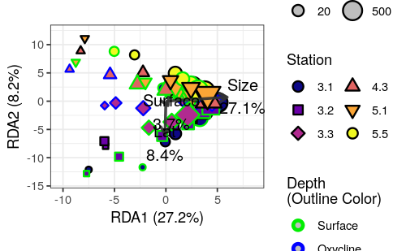

```r
plotNoFreeRda <- My_Constrained_RDA_Plot_Type1_wFort(rdaConstrained_NoFree) +
  scale_size(breaks = sqrt(filterSizes),
             labels = filterSizes, range = c(1.5,6))
plotNoFreeRda
```

# As above but without 0.2 or 1.2 micron data

```r
sampleData_NoSmall <- sampleData01 %>% filter(Size_Class > 2)
wideASVs_log_NoSmall <- wideASVs_log[rownames(wideASVs_log) %in% sampleData_NoSmall$ID,]
wideASVs_log_NoSmall <- wideASVs_log_NoSmall[match(sampleData_NoSmall$ID, rownames(wideASVs_log_NoSmall)),]
```

```r
rdaConstrained_NoSmall <- rda(wideASVs_log_NoSmall ~ lat + Depth2 + log10(Size_Class), data = sampleData_NoSmall)
```

```r
rdaConstrained_NoSmall
```

```
Call: rda(formula = wideASVs_log_NoSmall ~ lat + Depth2 + log10(Size_Class), data = sampleData_NoSmall)

                Inertia Proportion Rank
Total         5425.3372     1.0000
Constrained   1981.7754     0.3653    3
Unconstrained 3443.5618     0.6347   53
Inertia is variance

Eigenvalues for constrained axes:
  RDA1   RDA2   RDA3
1218.0  509.6  254.2

Eigenvalues for unconstrained axes:
  PC1   PC2   PC3   PC4   PC5   PC6   PC7   PC8
643.0 482.0 356.2 201.1 148.2 145.2 122.8 108.2
(Showing 8 of 53 unconstrained eigenvalues)
```

```r
anovaNoSmall <- anova(rdaConstrained_NoSmall, by = "margin", permutations = how(nperm=9999))
anovaNoSmall
```

```
Permutation test for rda under reduced model
Marginal effects of terms
Permutation: free
Number of permutations: 9999

Model: rda(formula = wideASVs_log_NoSmall ~ lat + Depth2 + log10(Size_Class), data = sampleData_NoSmall)
                  Df Variance       F Pr(>F)
lat                1    536.4  8.2560  1e-04 ***
Depth2             1    261.5  4.0243  1e-03 ***
log10(Size_Class)  1   1199.2 18.4566  1e-04 ***
Residual          53   3443.6
---
Signif. codes:  0 ‘***’ 0.001 ‘**’ 0.01 ‘*’ 0.05 ‘.’ 0.1 ‘ ’ 1
```

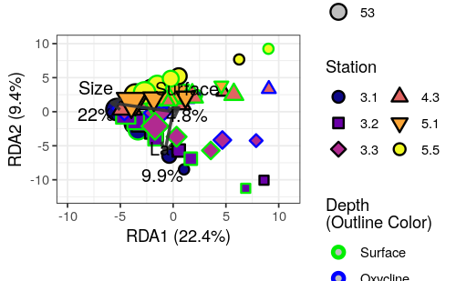

```r
plotNoSmallRda<- My_Constrained_RDA_Plot_Type1_wFort(rdaConstrained_NoSmall) + lims(x = c(-10, 11)) + scale_size(breaks = sqrt(filterSizes),
             labels = filterSizes, range = c(2.5,6))
plotNoSmallRda
```

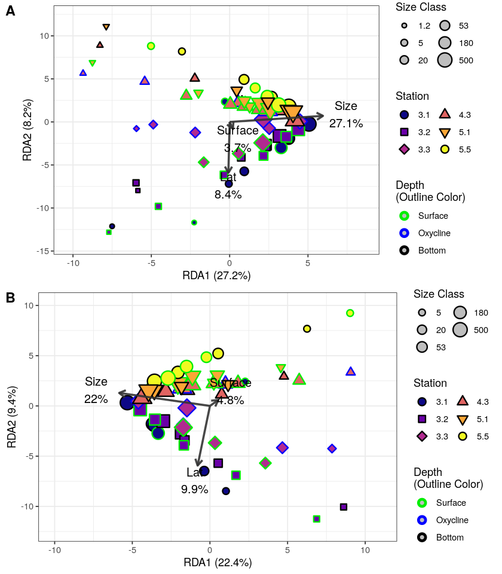

```r
plot_grid(plotNoFreeRda ,
                           plotNoSmallRda ,
                           labels = LETTERS, nrow = 2)
```

Cowplot the last two together so they can be one supplemental figure > These looked different from eachother. Check them.

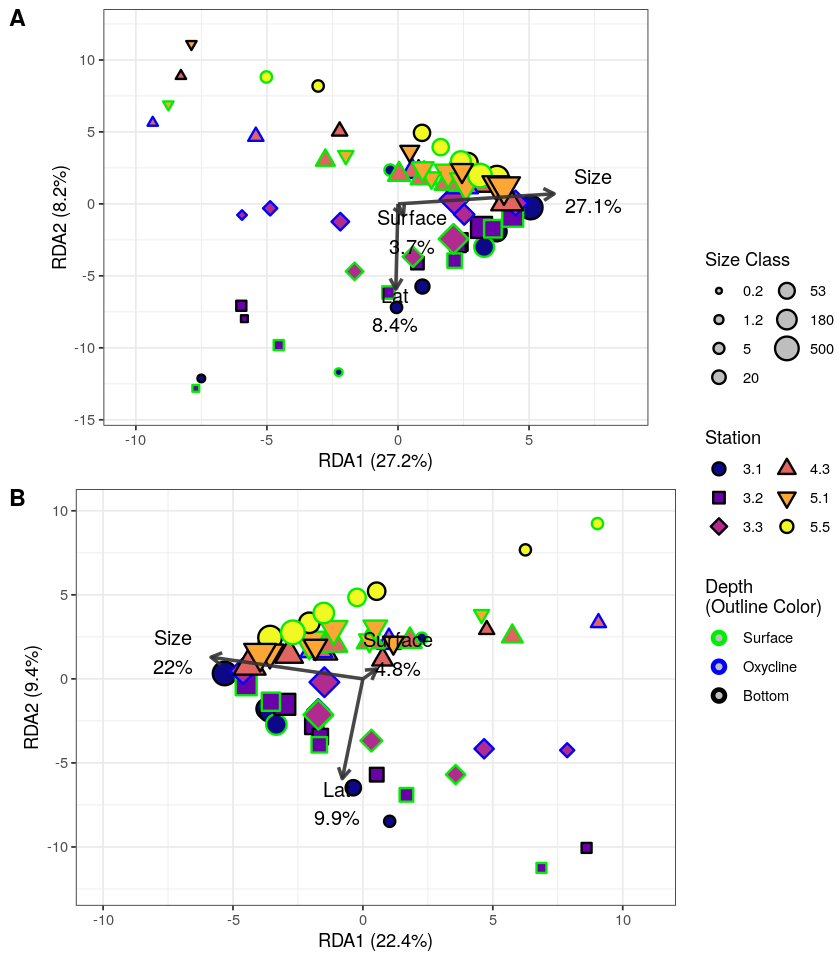

```r
# legend_rda <- get_legend(
#   plotNoFreeRda + theme(legend.box.margin = margin(0, 0, 0, 0))
#                          )

bigSubsetsRda0 <- plot_grid(plotNoFreeRda + theme(legend.position = "none"),
                           plotNoSmallRda + theme(legend.position = "none"),
                           labels = LETTERS, nrow = 2)
bigSubsetsRda <- plot_grid(bigSubsetsRda0, legend_rda, rel_widths = c(10, 2))
bigSubsetsRda
```

```r
ggsave(here::here("Figures", "bigSubsetsRda.png"), bigSubsetsRda, height = 8, width = 8)
ggsave(here::here("Figures", "bigSubsetsRda.svg"), bigSubsetsRda, height = 8, width = 8)
```

# Tables

```r
threeAnovas <- bind_rows(
mooAnova %>% broom::tidy() %>% mutate(dataset = "All"),
anovaNofree %>% broom::tidy() %>% mutate(dataset = "Particle Associated"),
anovaNoSmall %>% broom::tidy() %>% mutate(dataset = "≥ 5 Micron Particles")
) %>%
  select(Dataset = dataset, everything())
betaThreeTable <- threeAnovas %>%
  #mutate(`% Variance` = paste0(round(Variance/sum(Variance) * 100, 1), "%")) %>%
  group_by(Dataset) %>%
  mutate(`% Variance` = scales::percent(Variance/sum(Variance), accuracy = 0.1)) %>%

  mutate(term = recode(term, lat = "Latitude", Depth2 = "Depth", `sqrt(Size_Class)` = "√Size Class")) %>%
  select(Dataset, Term = term, DF = df, Variance, `% Variance`, T = statistic, p = p.value) %>%
    mutate(Variance = format(Variance, digits = 3),
         `% Variance` = format(`% Variance`, digits = 2),
         `T` = if_else(is.na(`T`), "", format(`T`, digits = 2)),
         p = if_else(p < 0.001, "< 0.001", paste0(" ", format(round(p, 3), digits = 1, scientific = FALSE)))
         ) %>%
  flextable() %>%
  align(j = -c(1), align = "right", part = "all") %>%
  bold(i = ~ p < 0.05, j = "p") %>%
  italic(j = "p", part = "header") %>%
  merge_v(j = "Dataset") %>%
  theme_vanilla() %>%
  identity()

betaThreeTable %>% save_as_docx(path = here::here("Tables", "betaThreeTable.docx"))
betaThreeTable
```

| Dataset | Term | DF | Variance | % Variance | T | p |
| --- | --- | --- | --- | --- | --- | --- |
| All | Latitude | 1 | 834 | 7.7% | 7.7 | < 0.001 |
|  | Depth | 1 | 356 | 3.3% | 3.3 | 0.002 |
|  | log10(Size_Class) | 1 | 1953 | 18.0% | 18.0 | < 0.001 |
|  | Residual | 71 | 7714 | 71.1% |  |  |
| Particle Associated | Latitude | 1 | 782 | 8.4% | 8.5 | < 0.001 |
|  | Depth | 1 | 349 | 3.7% | 3.8 | 0.002 |
|  | log10(Size_Class) | 1 | 2532 | 27.1% | 27.6 | < 0.001 |
|  | Residual | 62 | 5694 | 60.9% |  |  |
| ≥ 5 Micron Particles | Latitude | 1 | 536 | 9.9% | 8.3 | < 0.001 |
|  | Depth | 1 | 261 | 4.8% | 4.0 | 0.001 |
|  | log10(Size_Class) | 1 | 1199 | 22.0% | 18.5 | < 0.001 |
|  | Residual | 53 | 3444 | 63.3% |  |  |

# Comparing to environmental parameters

```r
rdaConstrained_env <- rda(wideASVs_log ~ Salinity + Depth2 + log10(Size_Class), data = sampleData01)
```

```r
anova(rdaConstrained_env, by = "margin")
```

```
Permutation test for rda under reduced model
Marginal effects of terms
Permutation: free
Number of permutations: 999

Model: rda(formula = wideASVs_log ~ Salinity + Depth2 + log10(Size_Class), data = sampleData01)
                  Df Variance       F Pr(>F)
Salinity           1    740.9  6.7384  0.001 ***
Depth2             1    264.3  2.4035  0.022 *
log10(Size_Class)  1   1948.2 17.7174  0.001 ***
Residual          71   7807.0
---
Signif. codes:  0 ‘***’ 0.001 ‘**’ 0.01 ‘*’ 0.05 ‘.’ 0.1 ‘ ’ 1
```

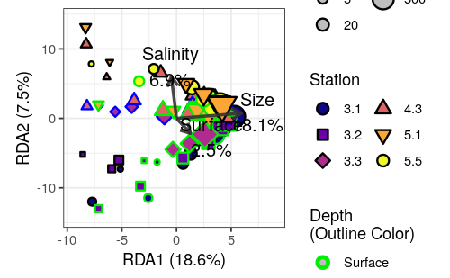

```r
My_Constrained_RDA_Plot_Type1_wFort(rdaConstrained_env)
```

```r
rdaConstrained_wdepth <- rda(wideASVs_log ~ Salinity + Depth_m  + log(Oxygen + 0.03) + log10(Size_Class), data = sampleData01)
anova(rdaConstrained_wdepth, by = "margin")
```

```
Permutation test for rda under reduced model
Marginal effects of terms
Permutation: free
Number of permutations: 999

Model: rda(formula = wideASVs_log ~ Salinity + Depth_m + log(Oxygen + 0.03) + log10(Size_Class), data = sampleData01)
                   Df Variance       F Pr(>F)
Salinity            1    721.8  6.7507  0.001 ***
Depth_m             1    128.4  1.2011  0.261
log(Oxygen + 0.03)  1    261.4  2.4451  0.021 *
log10(Size_Class)   1   2001.0 18.7147  0.001 ***
Residual           70   7484.6
---
Signif. codes:  0 ‘***’ 0.001 ‘**’ 0.01 ‘*’ 0.05 ‘.’ 0.1 ‘ ’ 1
```

```r
rdaConstrained_env3 <- rda(wideASVs_log ~ Salinity  + Oxygen + Depth_m + log10(Size_Class), data = sampleData01 %>% mutate(Oxygen = log(Oxygen + 0.03)))
mooAnova_Env3 <- anova(rdaConstrained_env3, by = "margin", permutations = 9999)
mooAnova_Env3
```

```
Permutation test for rda under reduced model
Marginal effects of terms
Permutation: free
Number of permutations: 9999

Model: rda(formula = wideASVs_log ~ Salinity + Oxygen + Depth_m + log10(Size_Class), data = sampleData01 %>% mutate(Oxygen = log(Oxygen + 0.03)))
                  Df Variance       F Pr(>F)
Salinity           1    721.8  6.7507 0.0001 ***
Oxygen             1    261.4  2.4451 0.0154 *
Depth_m            1    128.4  1.2011 0.2511
log10(Size_Class)  1   2001.0 18.7147 0.0001 ***
Residual          70   7484.6
---
Signif. codes:  0 ‘***’ 0.001 ‘**’ 0.01 ‘*’ 0.05 ‘.’ 0.1 ‘ ’ 1
```

```r
rdaConstrained_env2 <- rda(wideASVs_log ~ Salinity  + Oxygen + log10(Size_Class), data = sampleData01 %>% mutate(Oxygen = log(Oxygen + 0.03)))
mooAnova_Env <- anova(rdaConstrained_env2, by = "margin", permutations = 9999)
mooAnova_Env
```

```
Permutation test for rda under reduced model
Marginal effects of terms
Permutation: free
Number of permutations: 9999

Model: rda(formula = wideASVs_log ~ Salinity + Oxygen + log10(Size_Class), data = sampleData01 %>% mutate(Oxygen = log(Oxygen + 0.03)))
                  Df Variance       F Pr(>F)
Salinity           1    745.3  6.9503  1e-04 ***
Oxygen             1    458.2  4.2736  4e-04 ***
log10(Size_Class)  1   2001.9 18.6696  1e-04 ***
Residual          71   7613.0
---
Signif. codes:  0 ‘***’ 0.001 ‘**’ 0.01 ‘*’ 0.05 ‘.’ 0.1 ‘ ’ 1
```

## Run Env CCA

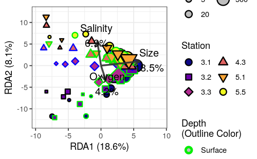

```r
EnvRDA <- My_Constrained_RDA_Plot_Type1_wFort(rdaConstrained_env2)
EnvRDA
```

```r
EnvRDA13 <- My_Constrained_RDA_Plot_Type1_wFort_13(rdaConstrained_env2)
```

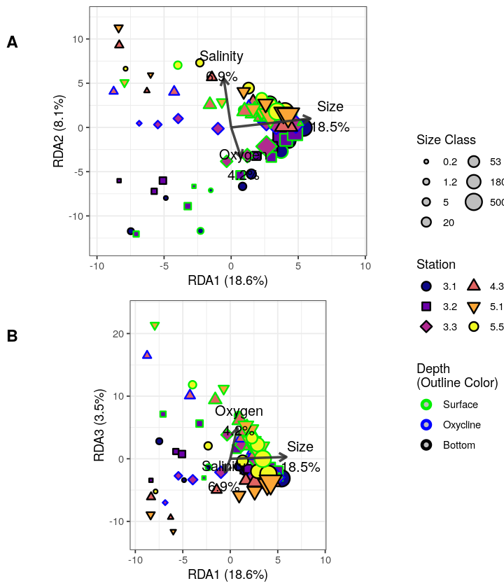

```r
EnvRDA123 <- plot_grid(
  plot_grid(
    EnvRDA + theme(legend.position = "none"),
    EnvRDA13 + theme(legend.position = "none"),
    ncol = 1, labels = c("A", "B"), label_y = 0.9
  ),
  legend_rda, rel_widths = c(10, 2)
)
EnvRDA123
```

```r
ggsave(here("Figures", "EnvRDA_12.png"), plot = EnvRDA, height = 4.5, width = 6)
ggsave(here("Figures", "EnvRDA_13.png"), plot = EnvRDA13, height = 5, width = 6)
ggsave(here("Figures", "EnvRDA_12.svg"), plot = EnvRDA, height = 4.5, width = 6)
ggsave(here("Figures", "EnvRDA_13.svg"), plot = EnvRDA13, height = 5, width = 6)
```

```r
ggsave(here("Figures", "EnvRDA_123.png"), plot = EnvRDA123, height = 7, width = 6)
ggsave(here("Figures", "EnvRDA_123.svg"), plot = EnvRDA123, height = 7, width = 6)
```

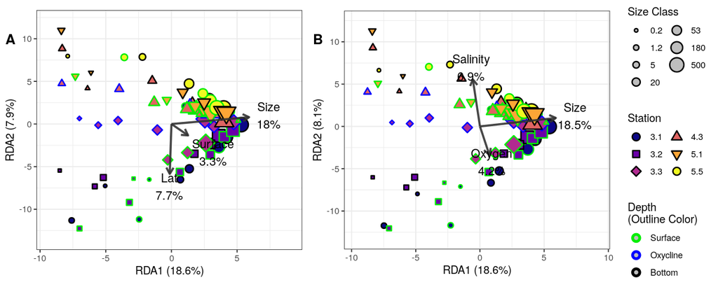

```r
combinedRDA <- plot_grid( mainRDA + theme(legend.position = "none"),
           EnvRDA + theme(legend.position = "none"),
           legend_rda, rel_widths = c(3,3,1), nrow = 1, labels = c("A", "B", ""), label_y = 0.9)
combinedRDA
```

sampleData_NoSmall <- sampleData01 %>% filter(Size_Class > 2) wideASVs_log_NoSmall <- wideASVs_log[rownames(wideASVs_log) %in% sampleData_NoSmall$ID,] wideASVs_log_NoSmall <- wideASVs_log_NoSmall[match(sampleData_NoSmall$ID, rownames(wideASVs_log_NoSmall)),]

Particle characteristics? Have to strike the 0.2 and omit any missing values.

```r
sampleData_MeasuredParticles <- sampleData01 %>%
  filter(!is.na(CarbonPerLiter_mg) & !is.na(MassperLiter))
wideASVs_log_MeasuredParticles <- wideASVs_log[match(sampleData_MeasuredParticles$ID, rownames(wideASVs_log)),]
```

```r
rdaConstrained_env_particles <- rda(wideASVs_log_MeasuredParticles ~ Salinity  + log(Oxygen + 0.03) + log10(Size_Class) + I(CarbonPerLiter_mg/MassperLiter) + I(NitrogenPerLiter_mg/CarbonPerLiter_mg) + `δ13CVPDB (‰)` + `δ15NAir (‰)`, data = sampleData_MeasuredParticles)
```

```r
extractAIC(rdaConstrained_env_particles)
```

```
[1]   8.0000 571.0925
```

```r
anova(rdaConstrained_env_particles, by = "margin")
```

```
Permutation test for rda under reduced model
Marginal effects of terms
Permutation: free
Number of permutations: 999

Model: rda(formula = wideASVs_log_MeasuredParticles ~ Salinity + log(Oxygen + 0.03) + log10(Size_Class) + I(CarbonPerLiter_mg/MassperLiter) + I(NitrogenPerLiter_mg/CarbonPerLiter_mg) + `δ13CVPDB (‰)` + `δ15NAir (‰)`, data = sampleData_MeasuredParticles)
                                         Df Variance       F Pr(>F)
Salinity                                  1    371.8  4.0800  0.001 ***
log(Oxygen + 0.03)                        1    390.4  4.2833  0.001 ***
log10(Size_Class)                         1   2393.4 26.2623  0.001 ***
I(CarbonPerLiter_mg/MassperLiter)         1     68.2  0.7485  0.528
I(NitrogenPerLiter_mg/CarbonPerLiter_mg)  1    123.2  1.3524  0.211
`δ13CVPDB (‰)`                            1    188.5  2.0681  0.053 .
`δ15NAir (‰)`                             1     69.1  0.7588  0.559
Residual                                 57   5194.7
---
Signif. codes:  0 ‘***’ 0.001 ‘**’ 0.01 ‘*’ 0.05 ‘.’ 0.1 ‘ ’ 1
```

```r
ordistep(rdaConstrained_env2)
```

```
Start: wideASVs_log ~ Salinity + Oxygen + log10(Size_Class)

                    Df    AIC       F Pr(>F)
- Oxygen             1 679.70  4.2736  0.005 **
- Salinity           1 682.32  6.9503  0.005 **
- log10(Size_Class)  1 692.82 18.6696  0.005 **
---
Signif. codes:  0 ‘***’ 0.001 ‘**’ 0.01 ‘*’ 0.05 ‘.’ 0.1 ‘ ’ 1

Call: rda(formula = wideASVs_log ~ Salinity + Oxygen + log10(Size_Class), data = sampleData01 %>% mutate(Oxygen
= log(Oxygen + 0.03)))

                Inertia Proportion Rank
Total         1.090e+04  1.000e+00
Constrained   3.284e+03  3.013e-01    3
Unconstrained 7.613e+03  6.987e-01   71
Inertia is variance

Eigenvalues for constrained axes:
  RDA1   RDA2   RDA3
2025.3  880.9  377.4

Eigenvalues for unconstrained axes:
   PC1    PC2    PC3    PC4    PC5    PC6    PC7    PC8
1718.1  861.2  632.8  576.1  293.6  249.8  238.8  208.4
(Showing 8 of 71 unconstrained eigenvalues)
```

# Squared terms

```r
rdaConstrained_env3 <- rda(wideASVs_log ~ Salinity + I(Salinity^2)  + Oxygen + Size + I(Size^2), data = sampleData01 %>%
                             mutate(Oxygen = log(Oxygen + 0.03),
                                    Size = log10(Size_Class)))
anova(rdaConstrained_env3, by = "margin")
```

```
Permutation test for rda under reduced model
Marginal effects of terms
Permutation: free
Number of permutations: 999

Model: rda(formula = wideASVs_log ~ Salinity + I(Salinity^2) + Oxygen + Size + I(Size^2), data = sampleData01 %>% mutate(Oxygen = log(Oxygen + 0.03), Size = log10(Size_Class)))
              Df Variance       F Pr(>F)
Salinity       1    319.3  3.3588  0.005 **
I(Salinity^2)  1    239.4  2.5183  0.017 *
Oxygen         1    279.1  2.9362  0.010 **
Size           1    960.6 10.1044  0.001 ***
I(Size^2)      1    802.4  8.4408  0.001 ***
Residual      69   6559.5
---
Signif. codes:  0 ‘***’ 0.001 ‘**’ 0.01 ‘*’ 0.05 ‘.’ 0.1 ‘ ’ 1
```

```r
rdaConstrained_position <- rda(wideASVs_log ~ Latitude + I(Latitude^2) + Depth + Size + I(Size^2), data = sampleData01 %>%
                        select(-Depth) %>%
                        rename(Latitude = lat, Depth = Depth2) %>%
                        mutate(Size = log10(Size_Class)))
anova(rdaConstrained_position, by = "margin")
```

```
Permutation test for rda under reduced model
Marginal effects of terms
Permutation: free
Number of permutations: 999

Model: rda(formula = wideASVs_log ~ Latitude + I(Latitude^2) + Depth + Size + I(Size^2), data = sampleData01 %>% select(-Depth) %>% rename(Latitude = lat, Depth = Depth2) %>% mutate(Size = log10(Size_Class)))
              Df Variance       F Pr(>F)
Latitude       1    319.7  3.3589  0.003 **
I(Latitude^2)  1    323.8  3.4018  0.003 **
Depth          1    338.5  3.5570  0.005 **
Size           1    969.7 10.1886  0.001 ***
I(Size^2)      1    816.1  8.5753  0.001 ***
Residual      69   6566.8
---
Signif. codes:  0 ‘***’ 0.001 ‘**’ 0.01 ‘*’ 0.05 ‘.’ 0.1 ‘ ’ 1
```

```r
rdaConstrained
```

```
Call: rda(formula = wideASVs_log ~ lat + Depth2 + log10(Size_Class), data = sampleData01)

                Inertia Proportion Rank
Total         1.090e+04  1.000e+00
Constrained   3.183e+03  2.921e-01    3
Unconstrained 7.714e+03  7.079e-01   71
Inertia is variance

Eigenvalues for constrained axes:
  RDA1   RDA2   RDA3
2030.6  856.5  296.0

Eigenvalues for unconstrained axes:
   PC1    PC2    PC3    PC4    PC5    PC6    PC7    PC8
1814.8  919.0  643.6  553.3  288.0  251.2  215.2  212.9
(Showing 8 of 71 unconstrained eigenvalues)
```

```r
rdaConstrained_position
```

```
Call: rda(formula = wideASVs_log ~ Latitude + I(Latitude^2) + Depth + Size + I(Size^2), data = sampleData01 %>%
select(-Depth) %>% rename(Latitude = lat, Depth = Depth2) %>% mutate(Size = log10(Size_Class)))

                Inertia Proportion Rank
Total         1.090e+04  1.000e+00
Constrained   4.330e+03  3.974e-01    5
Unconstrained 6.567e+03  6.026e-01   69
Inertia is variance

Eigenvalues for constrained axes:
  RDA1   RDA2   RDA3   RDA4   RDA5
2044.5 1065.6  791.0  285.5  143.3

Eigenvalues for unconstrained axes:
   PC1    PC2    PC3    PC4    PC5    PC6    PC7    PC8
1358.0  713.7  560.7  355.5  276.4  215.0  212.5  200.2
(Showing 8 of 69 unconstrained eigenvalues)
```

```r
rdaConstrained_env2
```

```
Call: rda(formula = wideASVs_log ~ Salinity + Oxygen + log10(Size_Class), data = sampleData01 %>% mutate(Oxygen
= log(Oxygen + 0.03)))

                Inertia Proportion Rank
Total         1.090e+04  1.000e+00
Constrained   3.284e+03  3.013e-01    3
Unconstrained 7.613e+03  6.987e-01   71
Inertia is variance

Eigenvalues for constrained axes:
  RDA1   RDA2   RDA3
2025.3  880.9  377.4

Eigenvalues for unconstrained axes:
   PC1    PC2    PC3    PC4    PC5    PC6    PC7    PC8
1718.1  861.2  632.8  576.1  293.6  249.8  238.8  208.4
(Showing 8 of 71 unconstrained eigenvalues)
```

```r
rdaConstrained_env3
```

```
Call: rda(formula = wideASVs_log ~ Salinity + I(Salinity^2) + Oxygen + Size + I(Size^2), data = sampleData01
%>% mutate(Oxygen = log(Oxygen + 0.03), Size = log10(Size_Class)))

                Inertia Proportion Rank
Total         10896.630      1.000
Constrained    4337.166      0.398    5
Unconstrained  6559.464      0.602   69
Inertia is variance

Eigenvalues for constrained axes:
  RDA1   RDA2   RDA3   RDA4   RDA5
2094.6  981.2  854.5  289.7  117.2

Eigenvalues for unconstrained axes:
   PC1    PC2    PC3    PC4    PC5    PC6    PC7    PC8
1200.4  830.8  586.3  363.4  271.6  218.5  206.8  188.5
(Showing 8 of 69 unconstrained eigenvalues)
```

```r
rdaConstrained %>% extractAIC()
```

```
[1]   4.0000 678.2985
```

```r
rdaConstrained_position %>% extractAIC()
```

```
[1]   6.0000 670.2265
```

```r
rdaConstrained_env2 %>% extractAIC()
```

```
[1]   4.0000 677.3146
```

```r
rdaConstrained_env3 %>% extractAIC()
```

```
[1]   6.0000 670.1431
```

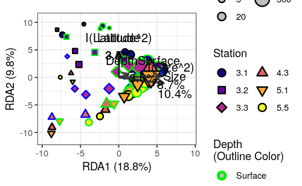

```r
positionRDA_Quadratic <- My_Constrained_RDA_Plot_Type1_wFort(rdaConstrained_position)
envRDA_Quadratic <- My_Constrained_RDA_Plot_Type1_wFort(rdaConstrained_env3)
positionRDA_Quadratic
```

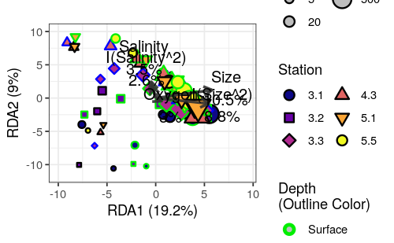

```r
envRDA_Quadratic
```

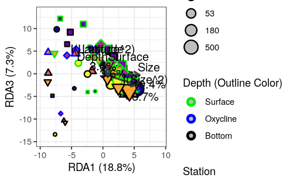

```r
My_Constrained_RDA_Plot_Type1_wFort_13(rdaConstrained_position)
```

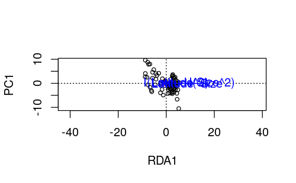

```r
plot(rdaConstrained_position, choices = c(1,6))
```

# No Free and Small, but this time with an environmental focus

rdaConstrained_env2 <- rda(wideASVs_log ~ Salinity + Oxygen + log10(Size_Class), data = sampleData01 %>% mutate(Oxygen = log(Oxygen + 0.03)))

```r
rdaConstrained_NoFree_Env <- rda(wideASVs_log_NoFree ~ Salinity + Oxygen + log10(Size_Class), data = sampleData_NoFree %>% mutate(Oxygen = log(Oxygen + 0.03)))
```

```r
rdaConstrained_NoFree_Env
```

```
Call: rda(formula = wideASVs_log_NoFree ~ Salinity + Oxygen + log10(Size_Class), data = sampleData_NoFree %>%
mutate(Oxygen = log(Oxygen + 0.03)))

                Inertia Proportion Rank
Total         9330.6524     1.0000
Constrained   3763.7561     0.4034    3
Unconstrained 5566.8963     0.5966   62
Inertia is variance

Eigenvalues for constrained axes:
  RDA1   RDA2   RDA3
2632.7  771.0  360.1

Eigenvalues for unconstrained axes:
  PC1   PC2   PC3   PC4   PC5   PC6   PC7   PC8
923.3 690.2 629.4 335.4 276.5 234.7 210.1 176.2
(Showing 8 of 62 unconstrained eigenvalues)
```

```r
anovaNofree_Env <- anova(rdaConstrained_NoFree_Env, by = "margin", permutations = how(nperm=9999))
```

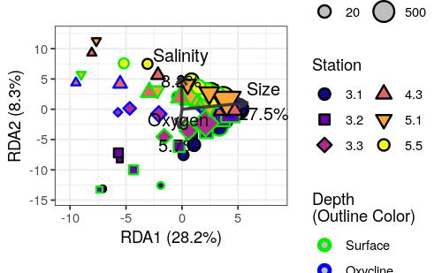

```r
plotNoFreeRda_Env <- My_Constrained_RDA_Plot_Type1_wFort(rdaConstrained_NoFree_Env) +
  scale_size(breaks = sqrt(filterSizes),
             labels = filterSizes, range = c(1.5,6))
plotNoFreeRda_Env
```

## As above but without 0.2 or 1.2 micron data

```r
rdaConstrained_NoSmall_Env <- rda(wideASVs_log_NoSmall ~ Salinity + Oxygen + log10(Size_Class), data = sampleData_NoSmall %>% mutate(Oxygen = log(Oxygen + 0.03)))
```

```r
rdaConstrained_NoSmall_Env
```

```
Call: rda(formula = wideASVs_log_NoSmall ~ Salinity + Oxygen + log10(Size_Class), data = sampleData_NoSmall %>%
mutate(Oxygen = log(Oxygen + 0.03)))

                Inertia Proportion Rank
Total         5425.3372     1.0000
Constrained   1980.6441     0.3651    3
Unconstrained 3444.6931     0.6349   53
Inertia is variance

Eigenvalues for constrained axes:
  RDA1   RDA2   RDA3
1333.0  433.6  214.0

Eigenvalues for unconstrained axes:
  PC1   PC2   PC3   PC4   PC5   PC6   PC7   PC8
636.4 430.2 398.5 233.0 152.8 136.1 120.8 105.0
(Showing 8 of 53 unconstrained eigenvalues)
```

```r
anovaNoSmall_Env <- anova(rdaConstrained_NoSmall_Env, by = "margin", permutations = how(nperm=9999))
anovaNoSmall_Env
```

```
Permutation test for rda under reduced model
Marginal effects of terms
Permutation: free
Number of permutations: 9999

Model: rda(formula = wideASVs_log_NoSmall ~ Salinity + Oxygen + log10(Size_Class), data = sampleData_NoSmall %>% mutate(Oxygen = log(Oxygen + 0.03)))
                  Df Variance       F Pr(>F)
Salinity           1    533.6  8.2093  1e-04 ***
Oxygen             1    431.5  6.6398  1e-04 ***
log10(Size_Class)  1   1228.9 18.9076  1e-04 ***
Residual          53   3444.7
---
Signif. codes:  0 ‘***’ 0.001 ‘**’ 0.01 ‘*’ 0.05 ‘.’ 0.1 ‘ ’ 1
```

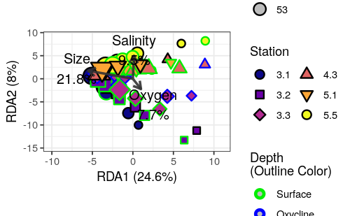

```r
plotNoSmallRda_Env<- My_Constrained_RDA_Plot_Type1_wFort(rdaConstrained_NoSmall_Env) + lims(x = c(-10, 11)) + scale_size(breaks = sqrt(filterSizes),
             labels = filterSizes, range = c(2.5,6))
plotNoSmallRda_Env
```

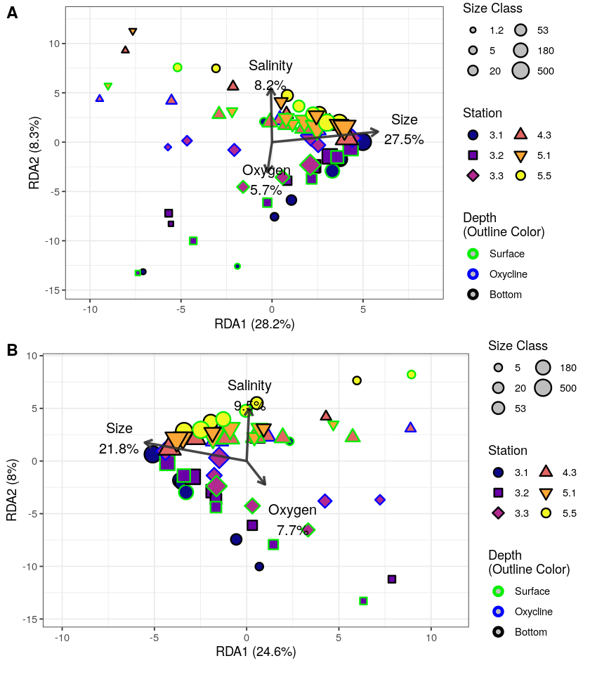

```r
plot_grid(plotNoFreeRda_Env ,
                           plotNoSmallRda_Env ,
                           labels = LETTERS, nrow = 2)
```

Cowplot the last two together so they can be one supplemental figure

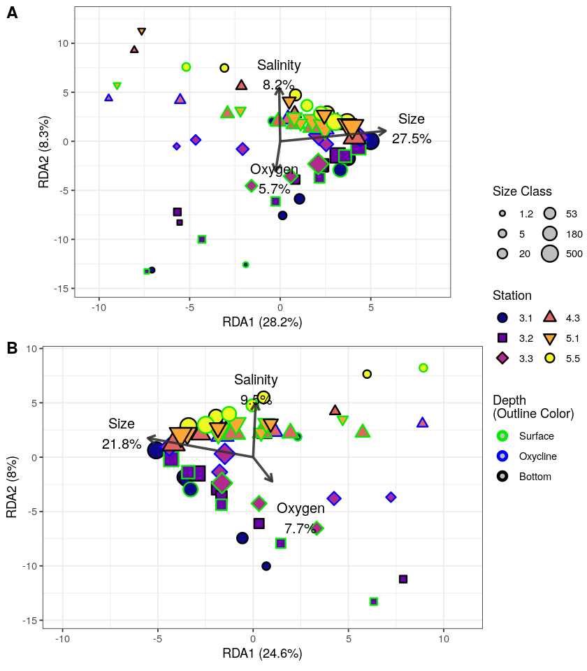

```r
legend_rda <- get_legend(
  plotNoFreeRda_Env + theme(legend.box.margin = margin(0, 0, 0, 0))
                         )

bigSubsetsRda0_Env <- plot_grid(plotNoFreeRda_Env + theme(legend.position = "none"),
                           plotNoSmallRda_Env + theme(legend.position = "none"),
                           labels = LETTERS, nrow = 2)
bigSubsetsRda_Env <- plot_grid(bigSubsetsRda0_Env, legend_rda, rel_widths = c(10, 2))
bigSubsetsRda_Env
```

```r
ggsave(here::here("Figures", "bigSubsetsRda_Env.png"), bigSubsetsRda_Env, height = 8, width = 8)
ggsave(here::here("Figures", "bigSubsetsRda_Env.svg"), bigSubsetsRda_Env, height = 8, width = 8)
```

# Tables with Enviornmental Frame

```r
threeAnovas_Env <- bind_rows(
mooAnova_Env %>% broom::tidy() %>% mutate(dataset = "All"),
anovaNofree_Env %>% broom::tidy() %>% mutate(dataset = "Particle Associated"),
anovaNoSmall_Env %>% broom::tidy() %>% mutate(dataset = "≥ 5 Micron Particles")
) %>%
  select(Dataset = dataset, everything())
betaThreeTable_Env <- threeAnovas_Env %>%
  group_by(Dataset) %>%
  #mutate(`% Variance` = paste0(round(Variance/sum(Variance) * 100, 1), "%")) %>%
  mutate(`% Variance` = scales::percent(Variance/sum(Variance), accuracy = 0.1)) %>%

  mutate(term = recode(term, lat = "Latitude", Depth2 = "Depth", `log10(Size_Class)` = "log10(Size Class)")) %>%
  select(Dataset, Term = term, DF = df, Variance, `% Variance`, T = statistic, p = p.value) %>%
    mutate(Variance = format(Variance, digits = 3),
         `% Variance` = format(`% Variance`, digits = 2),
         `T` = if_else(is.na(`T`), "", format(`T`, digits = 2)),
         p = if_else(p < 0.001, "< 0.001", paste0(" ", format(round(p, 3), digits = 1, scientific = FALSE)))
         ) %>%
  flextable() %>%
  align(j = -c(1), align = "right", part = "all") %>%
  bold(i = ~ p < 0.05, j = "p") %>%
  italic(j = "p", part = "header") %>%
  merge_v(j = "Dataset") %>%
  theme_vanilla() %>%
  identity()

betaThreeTable_Env %>% save_as_docx(path = here::here("Tables", "betaThreeTable_Env.docx"))
betaThreeTable_Env
```

| Dataset | Term | DF | Variance | % Variance | T | p |
| --- | --- | --- | --- | --- | --- | --- |
| All | Salinity | 1 | 745 | 6.9% | 7.0 | < 0.001 |
|  | Oxygen | 1 | 458 | 4.2% | 4.3 | < 0.001 |
|  | log10(Size Class) | 1 | 2002 | 18.5% | 18.7 | < 0.001 |
|  | Residual | 71 | 7613 | 70.4% |  |  |
| Particle Associated | Salinity | 1 | 781 | 8.2% | 8.7 | < 0.001 |
|  | Oxygen | 1 | 546 | 5.7% | 6.1 | < 0.001 |
|  | log10(Size Class) | 1 | 2616 | 27.5% | 29.1 | < 0.001 |
|  | Residual | 62 | 5567 | 58.5% |  |  |
| ≥ 5 Micron Particles | Salinity | 1 | 534 | 9.5% | 8.2 | < 0.001 |
|  | Oxygen | 1 | 432 | 7.7% | 6.6 | < 0.001 |
|  | log10(Size Class) | 1 | 1229 | 21.8% | 18.9 | < 0.001 |
|  | Residual | 53 | 3445 | 61.1% |  |  |